# 05-The description of networks

Pedro Jordano

April 2, 2019

## Basic description of a network

There are a number of descriptors for a network. Generally just too many. In my opinion, the most important thing when analyzing ecological network properties is to have a clear idea of the biological meaning of these indexes. I mean, to have a sound biological interpretation of the variation we found and report in our study. The `R` package `bipartite`, for example, provides up to 34 different indexes within its `networklevel` function. We should use just those relevant to our ecological questions in our analysis, and be able to give proper biological interpretation of their results. The `bipartite` package provides worked examples (see e.g., fucntion `networstats`) illustrating specific analysis with a clear biological motivation, such as the analysis presented by (1).

Among the many packages in `R` used for network analysis, the following ones are the most frequently used, together with some general-purpose packages also included.

```r
## Classic analysis tools.
# require(statnet)  # A general package for network analysis.
require(sna)        # General package for network analysis.
require(network)     # General package for network analysis.
require(igraph)     # General package for network analysis.
require(intergraph) # Format exchange for networks.
require(bipartite)  # Statistical analysis for bipartite networks.
require(networksis) # Network models; simulation of bipartite graphs.
require(tnet)       # Statistical analysis of bipartite networks.
require(ggnet2)     # Included in the GGally utilities (see below).
require(ggnetwork)  # Networks plotting in ggplot2 grammar.

## Packages within the tidyverse framework and utils.
require(devtools)   # Tools for development packages.
require(ggplot2)    # Data visualisations using the 'Grammar of Graphics'.
require(GGally)     # GGally extends ggplot2 by adding several functions.
require(tidyverse)  # For general data manipulation and visualization.
require(tidygraph)  # For manipulating and analyzing network graphs.
require(ggnetwork)  # Network visualization in ggplot2.
require(ggraph)     # Visualizing objects created with the tidygraph package.

## The htmlwidgets set of packages makes it possible to use R to
## create interactive JavaScript visualizations.
require(networkD3)  # Dynamic visualizations.
require(bipartiteD3)# D3 plots for bipartite networks.
require(visNetwork)
require(RSiena)     # Fits statistical models to longitudinal sets of networks.

## Ecological data analysis packages useful with network analysis.
require(vegan)      # General package for ecological data analysis.
require(ade4)       # General package for ecological data analysis.
require(ape)        # Phylogenetic data analysis
require(picante)    # Phylogenetic data analysis

## Sourcing functions and packages
# I'm sourcing here these functions yet they should be available if you have my package `ggbipart` installed.
# Source the functions files
source("./code/sourcedir.R")
sourceDir("./code/functions/")
```

```r
# Read a network
# Where file data.txt has a weighted adjacency matrix, e.g.,:
#     Aa    Ab  Ac  Ba  Bb  Bc  Bd  Ca  Cb  Cc  Da
# P1    139 60   9  23  4   104 5   3   5   2   1
# P2    184 26  6   10  3   6   17  11  3   1   0
# P3    131 74  33  36  13  19  0   9   1   1   0
# P4    87  40  38  21  13  0   9   0   0   0   0
# P5    100 42  17  12  4   1   1   0   0   0   0
# P6    21  15  7   0   4   1   1   0   0   0   0
# P7    42  16  3   0   2   0   0   0   0   0   0
# P8    31  8   4   5   1   2   0   0   0   0   0
# P9    46  8   2   0   3   0   0   0   0   0   0
# P10   86  0   0   12  0   2   0   0   0   0   0
# P11   23  8   1   5   1   0   0   0   0   0   0
# P12   13  6   1   1   1   0   0   0   0   0   0
# P13   5   0   1   0   0   0   0   0   0   0   0
# P14   9   1   0   0   0   0   0   0   0   0   0

# A bipartite graph from adjacency matrix text file ----------------------
mymat <- as.matrix(read.table("./data/data.txt",
                              header= T, sep= "\t", dec= ".",
                              na.strings= "NA",
                              row.names= 1))
source("./code/sourcedir.R")
sourceDir("./code/functions")
```

```
## bip_binplot.R :
## bip_edgewt.R :
## bip_ggnet.R :
## bip_igplot.R :
## bip_init_igraph.R :
## bip_init_network.R :
## bip_qtplot.R :
## bip_railway.R :
## ggbipart.R :
## matfills.R :
## pairwise.R :
## plot_int_frqdistr.R :
## vectorize.R :
```

```r
mymat.net<- bip_init_network(mymat)
```

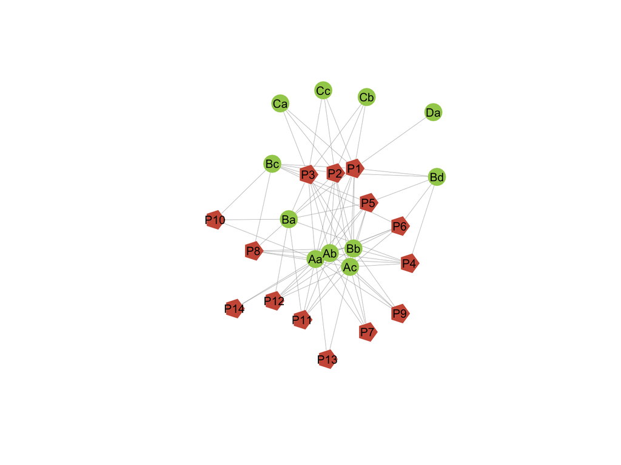

```r
bip_binplot(mymat, mymat.net,
                   vertex.cex=3,
                   label.cex= 0.9)
```

### 1. Size

The most basic characteristic of a network is its size. The size is simply the number of members, usually called nodes, vertices or actors. The `network.size()` function is the easiest way to get this. The basic summary of a statnet network object also provides this information, among other things. The size of a unipartite adjacency matrix $M$ is given by its $m$ nodes. The size of a bipartite adjacency matrix $M$ is given by the sum of its $m$ nodes in the lower level (one of the modes) and its $n$ nodes in the upper level.

Here are the basic networks descriptors:

```r
# Network size
#
network.size(mymat.net)
```

```
## [1] 25
```

```r
mymat.net
```

```
##  Network attributes:
##   vertices = 25
##   directed = FALSE
##   hyper = FALSE
##   loops = FALSE
##   multiple = FALSE
##   bipartite = 14
##   total edges= 80
##     missing edges= 0
##     non-missing edges= 80
##
##  Vertex attribute names:
##     mode vertex.names
##
##  Edge attribute names:
##     weights
```

```r
# Basic network data
summary(mymat.net)
```

```
## Network attributes:
##   vertices = 25
##   directed = FALSE
##   hyper = FALSE
##   loops = FALSE
##   multiple = FALSE
##   bipartite = 14
##  total edges = 80
##    missing edges = 0
##    non-missing edges = 80
##  density = 0.26667
##
## Vertex attributes:
##
##  mode:
##    character valued attribute
##    attribute summary:
##  A  P
## 11 14
##   vertex.names:
##    character valued attribute
##    25 valid vertex names
##
## Edge attributes:
##
##  weights:
##    numeric valued attribute
##    attribute summary:
##    Min. 1st Qu.  Median    Mean 3rd Qu.    Max.
##     1.0     2.0     8.0    21.5    21.5   184.0
##
## Network edgelist matrix:
##       [,1] [,2]
##  [1,]   15    1
##  [2,]   16    1
##  [3,]   17    1
##  [4,]   18    1
##  [5,]   19    1
##  [6,]   20    1
##  [7,]   21    1
```

[output cut: 29 more lines]

```
## [37,]   15    5
## [38,]   16    5
## [39,]   17    5
## [40,]   18    5
## [41,]   19    5
## [42,]   20    5
## [43,]   21    5
## [44,]   15    6
## [45,]   16    6
## [46,]   17    6
## [47,]   19    6
## [48,]   20    6
## [49,]   21    6
## [50,]   15    7
##  [ reached getOption("max.print") -- omitted 30 rows ]
```

Here are all the networks descriptors available in `R` package `bipartite`, function `networklevel`, and then my preferred set of descriptors:

```r
# Network descriptors, all.
#
networklevel(Safariland, index="ALLBUTDD") #excludes degree distribution fits
```

```
##                       connectance                     web asymmetry
##                          0.160494                          0.500000
##                 links per species            number of compartments
##                          1.083333                          2.000000
##             compartment diversity               cluster coefficient
##                          1.496219                          0.111111
##                        nestedness                              NODF
##                         21.059281                         24.547804
##               weighted nestedness                     weighted NODF
##                          0.391718                         11.606374
##    interaction strength asymmetry          specialisation asymmetry
##                          0.390727                         -0.163314
##                   linkage density              weighted connectance
##                          1.602537                          0.044515
##                      Fisher alpha                 Shannon diversity
##                          7.833790                          1.582490
##              interaction evenness      Alatalo interaction evenness
##                          0.288089                          0.409819
##                                H2              number.of.species.HL
##                          0.853731                         27.000000
##              number.of.species.LL mean.number.of.shared.partners.HL
##                          9.000000                          0.472934
## mean.number.of.shared.partners.LL            cluster.coefficient.HL
##                          0.444444                          0.153097
##            cluster.coefficient.LL   weighted.cluster.coefficient.HL
##                          0.281678                          0.381097
##   weighted.cluster.coefficient.LL                  niche.overlap.HL
##                          0.060660                          0.327765
##                  niche.overlap.LL                   togetherness.HL
##                          0.047945                          0.160684
##                   togetherness.LL                        C.score.HL
##                          0.035294                          0.561610
##                        C.score.LL                        V.ratio.HL
##                          0.770425                          0.580645
##                        V.ratio.LL                    discrepancy.HL
##                          6.492857                         21.000000
##                    discrepancy.LL               extinction.slope.HL
##                         16.000000                          2.672792
##               extinction.slope.LL                     robustness.HL
##                          1.284086                          0.723240
##                     robustness.LL     functional.complementarity.HL
##                          0.558842                       1683.804207
##     functional.complementarity.LL              partner.diversity.HL
##                       1627.118573                          0.176867
##              partner.diversity.LL                     generality.HL
##                          0.608962                          1.248085
##                  vulnerability.LL
##                          1.956990
```

```r
# My preferred set of descriptors for ecological networks
networklevel(Safariland,
             index= c("connectance",
                      "weighted connectance",
                      "web asymmetry",
                      "links per species",
                      "number of compartments",
                      "cluster coefficient",
                      "NODF",
                      "weighted NODF",
                      "ISA",
                      "SA",
                      "Fisher alpha",
                      "interaction evenness",
                      "Shannon diversity",
                      "H2"),
             level="both", weighted=TRUE,
             ISAmethod="dependence",
             nrep = 100, normalise=TRUE, empty.web=TRUE,
             logbase="e", intereven="prod",
             H2_integer=TRUE, fcweighted=TRUE,
             fcdist="euclidean", legacy=FALSE)
```

```
##              connectance            web asymmetry        links per species
##                 0.160494                 0.500000                 1.083333
##   number of compartments      cluster coefficient                     NODF
##                 2.000000                 0.111111                24.547804
##            weighted NODF specialisation asymmetry     weighted connectance
##                11.606374                -0.163314                 0.044515
##             Fisher alpha        Shannon diversity     interaction evenness
##                 7.833790                 1.582490                 0.288089
##                       H2   cluster.coefficient.HL   cluster.coefficient.LL
##                 0.853731                 0.153097                 0.281678
```

### 2. Density

Of all the basic characteristics of a network, density is among the most important as well as being one of the easiest to understand.

Density, also known as connectance, is the proportion of observed links (also called ties, edges, arcs, or relations) in a network to the maximum number of possible links (2). Thus, density is a ratio that can range from 0 to 1. The closer to 1 the density is, the more interconnected is the network.

Density is relatively easy to calculate, although the underlying equation differs based on whether the network links are directed or undirected. It also varies for unipartite and bipartite networks.

An undirected link is one with no direction. Collaboration would be a good example of an undirected link; if A collaborates with B, then by necessity B is also collaborating with A. Directed links, on the other hand, have direction. Money flow is a good example of a directed link Also, trophic interactions in a food web, where energy flows from prey top predators, etc. Just because A gives money to B, does not necessarily mean that B reciprocates.

For a directed network, the maximum number of possible link among $k$ actors is
$$k ∗ (k − 1)$$
, so the formula for density is:
$$\frac{L}{k(k−1)}$$

where $L$ is the number of observed ties in the network. Density, as defined here, does not allow for links between a particular node and itself (called a loop).

For an undirected network the maximum number of links is $k ∗ (k − 1)/2$ because non-directed links should only be counted once for every dyad (i.e., pair of nodes). So, density for an undirected network becomes:

$$\frac{2L}{k(k−1)}$$

This is valid for one-mode, undirected networks. Bipartite networks frequently have a different number of nodes between the two component modes. For example, in a plant-pollinator assemblage the number of pollinator species $A$ is usually larger than the number of plant species, $P$. So, the density of a bipartite network is given by (2):

$$\frac{L}{{k_A}{k_P}}$$

where `k_Ak_P` is the maximum number of possible links (adjacency matrix size).

We could then use `R` to calculate density by hand, but it is easier to simply use the `gden()` function in `statnet`. The appropriate statistics for connectance for bipartite networks are included in the package `bipartite`. Also note that the `summary` function of any network object will report its density.

```r
# Connectance
gden(mymat.net)
```

```
## [1] 0.26667
```

```r
# For the Safariland dataset in library(bipartite)
SFL.net<- bip_init_network(Safariland)
gden(SFL.net)
```

```
## [1] 0.061905
```

```r
# Using bipartite package, very basic description, including connecetance and other indexes.
networklevel(Safariland, index="info")
```

```
##            connectance          web asymmetry      links per species
##                0.16049                0.50000                1.08333
## number of compartments   number.of.species.HL   number.of.species.LL
##                2.00000               27.00000                9.00000
```

### 3. Degree

Although the overall size of a network may be interesting, a more useful characteristic of the network is how connected it is, given its size and degree of node connectedness.

The degree of a node, `k`, is the number of links it has with other nodes in the network. In bipartite graphs those links occur only between nodes of different modes, e.g., plant species linked with animal species but not linked among them.

```r
# Using bipartite package
networklevel(Safariland, index="info")
```

```
##            connectance          web asymmetry      links per species
##                0.16049                0.50000                1.08333
## number of compartments   number.of.species.HL   number.of.species.LL
##                2.00000               27.00000                9.00000
```

Connectance is the realized proportion of potential links (3): sum of links divided by number of cells in the matrix (= number of higher times number of lower trophic level species). This is the standardized number of species combinations often used in co-occurrence analyses (4).

To get the frequency distributions of degrees for the lower (e.g., plant) and upper (e.g., animals) levels we can use a simple function that just plots the histograms for $k_P$ and $k_A$, the vectors of degrees for each mode:

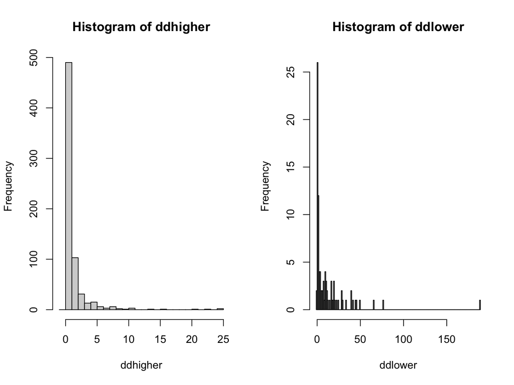

```r
# Degree distribution
#
# Assign dataset as, e.g., degreedistrib(mat), where mat is any binary matrix
# with or without row/col labels.

# This is the function.
degreedistrib<-function(mat, fit, ...) {
    par(mfrow= c(1,2))
    mat<- ifelse(mat==0,0,1)
# For plants (higher trophic level)
    ddhigher <- colSums(mat)     # Plants
    hih <- hist(ddhigher, -1:max(ddhigher), plot = T)$intensities
    hih

# For animals (lower trophic level)
    ddlower <- rowSums(mat)      # Animals
    rm<-max(rowSums(mat))
    hil <- hist(ddlower, -1:max(ddlower), plot = T)$intensities
    hil
}

degreedistrib(kato1990)
```

We can also easily obtain the degree distribution with function `degreedistr` in `R` package `bipartite`, which gives the fits of the cumulative distribution to different theoretical models. The analysis of goodness-of-fit of the degree distributions to theoretical models is best suited for large (very large) networks, where the fits can be robsutly estimated on the basis of a large number of distinct degree values. Thi sis not possible in the (usually) small- to medium-size networks frequently analyzed in ecological studies.

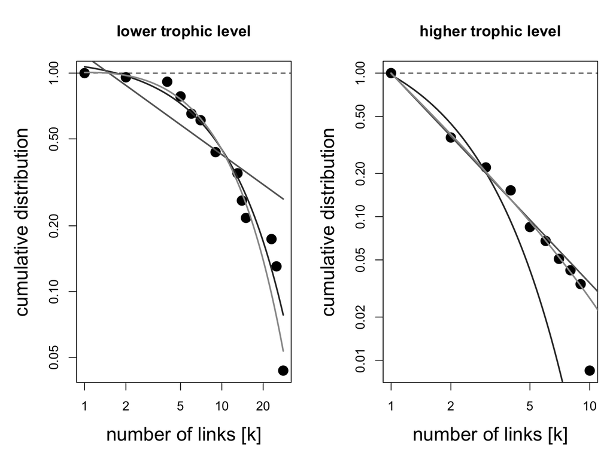

```
## $`lower level dd fits`
##                      Estimate Std. Error       Pr(>|t|)      R2      AIC
## exponential          0.096886  0.0068247 0.000000020318 0.98742 -34.3892
## power law            0.453753  0.0779320 0.000115441378 0.88691  -5.9716
## truncated power law -0.137660  0.0656622 0.062443935632 0.99158 -37.0923
##
## $`higher level dd fits`
##                     Estimate Std. Error         Pr(>|t|)      R2     AIC
## exponential           0.7828   0.080922 0.00001086972497 0.99139 -27.325
## power law             1.4622   0.034494 0.00000000010572 0.99896 -51.835
## truncated power law   1.3243   0.105996 0.00000484747542 0.99915 -52.443
```

```r
# Degree distribution for both levels.
degreedistr(elberling1999, subsample=1, seed=NULL)
```

### 4. Clustering: the different forms of node aggregation

```r
# Clustering for bipartite network.
clustering_tm(olesen2002flores, subsample=1, seed=NULL)
```

```
## [1] 0.27807
```

```r
clustering_tm(Safariland, subsample=1, seed=NULL)
```

```
## [1] 0.28571
```

```r
clustering_tm(elberling1999, subsample=1, seed=NULL)
```

```
## [1] 0.73351
```

```r
clustering_tm(kevan1970, subsample=1, seed=NULL)
```

```
## [1] 0.77916
```

## Topology

An adjacency matrix:

$$\left(\begin{array}{cccc}0 & 1 & 1 & 1 \\1 & 0 & 1 & 0 \\1 & 1 & 0 & 0 \\1 & 0 & 0 & 0\end{array}\right)$$

The following `R` code specifies the matrix $A$ depicted above, and calculates and prints the largest eigenvalue and the associated eigenvector.

```r
# Specify the adjacency matrix
A <- matrix(c(0,1,1,1,1,0,1,0,1,1,0,0,1,0,0,0 ),4,4, byrow= TRUE)
EV <- eigen(A)          # compute eigenvalues and eigenvectors

EV$values               # Eigenvalues
max(EV$values)          # Find the maximum eigenvalue

# get the eigenvector associated with the largest eigenvalue
centrality <- data.frame(EV$vectors[,1])
names(centrality) <- "Centrality"
print(centrality)
```

The absolute values are proportional to the measures of eigenvector centrality for each vertex in the network.

```
Vertex  EV Centrality
1       .6116285
2       .5227207
3       .5227207
4       .2818452
```

We can see that vertex 1 has the highest measure of eigenvector centrality, followed by #2 and #3, and #4 as the lowest values.

## Structure

### Nestedness

Nestedness is a property of secondary structure of a network. It indicates to what extent the interactions of less connected nodes form proper subets of the interactions of more connected nodes. So, a high nestedness indicates a tendency for the interactions of the nodes with greater interaction specificity to be included among those of the nodes with progressively higher generalization.

In this figure, the left panel shows an adjacency matrix for a perfectly nested network: the three interactions (white squares) of animal species #8 are included among those of the more generalized animal species #1. And the whole range of interaction richness among nodes forms a perfect gradient. In panel right matrix, the interactions are distributed randomly among nodes.

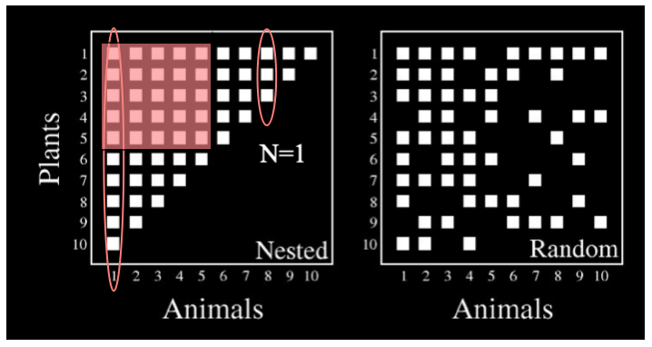

nestedness

There are a number of ways to estimate nestedness, usually suing the `bipartite` package (6) just to get the values according to several nestedness indices, and the `vegan`package (7), used to test the statistical significance of an empirical nestedness value.

A recommended index for nestedness, called `nestednodf` in `vegan` is `NODF`. High values indicate nestedness. According to the analysis of (8), NODF is more consistent and “better” than other measures of nestedness. There is also a quantitative measure of nestedness (8).

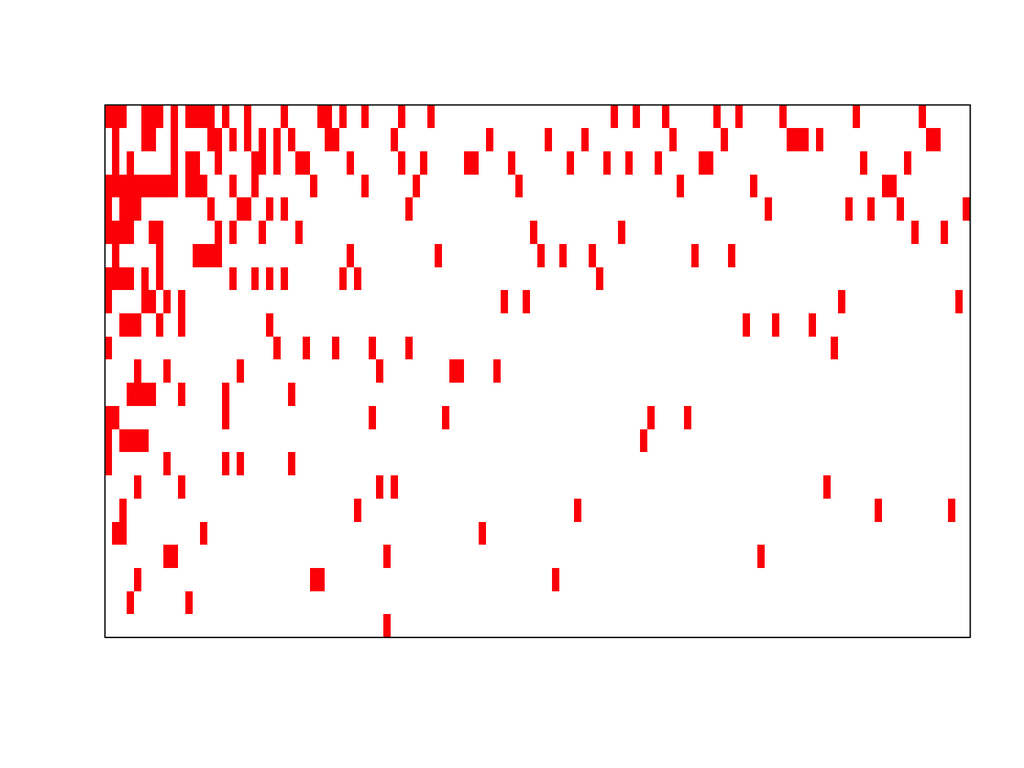

```r
# Nestedness
library(vegan)

## Use oecosimu to assess the non-randomness of nestedness statistics.
out1<- nestednodf(elberling1999, order= TRUE)
plot(out1)
```

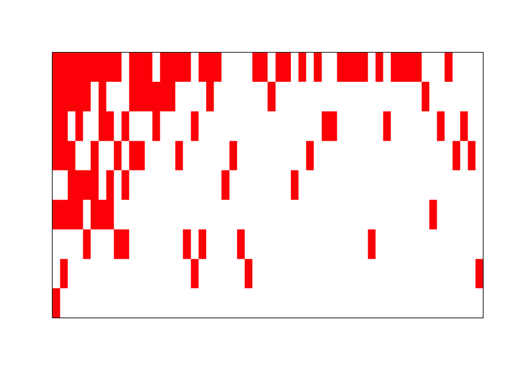

```r
out2<- nestednodf(ollerton2003, order= TRUE)
plot(out2)
```